# Práctica 2: Vecinos Próximos y Regresión Logística

Practica realizada por Tomas Higuera Viso y Alejandro Naranjo Jimenez

Importamos todas las librerias que usaremos en el notebook

```python
from Datos import Datos
from plotModel import plotModel
from IPython.display import *
from plot_notebook import *

import p2_scikit
import EstrategiaParticionado
import Clasificador
import numpy as np
import matplotlib.pyplot as plt
```

## Clasificador Vecinos Proximos

En este apartado utilizaremos el algoritmo de clasificacion vecinos proximos, usaremos distintos valores de k para comaprar las probabilidades. Los valores de k que usaremos son 1,3,5,11,21,51. La razon de usar valores impares es evitar problemas con los empates. En las pruebas de este algoritmo usaremos validacion cruzada.

Declaramos la estrategia de particionado.

```python
estrategia=EstrategiaParticionado.ValidacionCruzada(5)
```

Declaracion de la lista que contiene los valores K con los que se ejecutara el algoritmo.

```python
lista_k = [1, 3, 5, 11, 21, 51]
```

### example1.data

Ejecutaremos el algoritmo de vecinos proximos con el conjunto de datos example1. Ejecutaremos el algoritmo tanto normalizado como sin normalizar para comparar los resultados.

```python
dataset=Datos('data/example1.data')
```

```python
tabla1 = exe_KNN(dataset,estrategia, lista_k, True)

print("**Tasa de error [media ± desv.tip]**")
display(HTML(tabla1))
```

```
**Tasa de error [media ± desv.tip]**
```

| k | Sin Normalizar | Normalizando |
| --- | --- | --- |
| 1 | 0.1575 ± 0 | 0.0225 ± 0 |
| 3 | 0.0608 ± 0 | 0.0100 ± 0 |
| 5 | 0.0385 ± 0 | 0.0121 ± 0 |
| 11 | 0.1007 ± 0 | 0.0681 ± 0 |
| 21 | 0.0994 ± 0 | 0.0940 ± 0 |
| 51 | 0.1025 ± 0 | 0.1187 ± 0 |

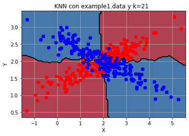

```python
exe_KNN_plot(dataset,estrategia,21,"example1.data",False)
```

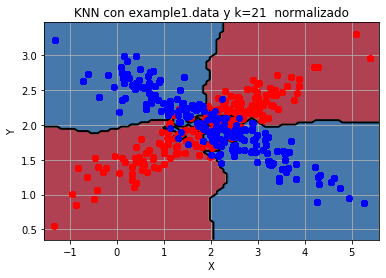

```python
exe_KNN_plot(dataset,estrategia,21,"example1.data",True)
```

Como podemos observar ambas soluciones, tanto normalizadas como sin normalizar obtienen resultados muy parejos. Las tasas de error a pesar de ser parecidas en general son menores las del caso normalizado.

### example2.data

Debido al tipo de datos, no se hara la normalizacion con este conjunto, ya que tratamos con datos discretos y no tiene sentido hacerlo.

```python
dataset=Datos('data/example2.data')
```

```python
table2 = exe_KNN(dataset,estrategia, lista_k, False)

print("**Tasa de error [media ± desv.tip]**")
display(HTML(table2))
```

```
**Tasa de error [media ± desv.tip]**
```

| k | Sin Normalizar |
| --- | --- |
| 1 | 0.0000 ± 0 |
| 3 | 0.0000 ± 0 |
| 5 | 0.0000 ± 0 |
| 11 | 0.0000 ± 0 |
| 21 | 0.0000 ± 0 |
| 51 | 0.0000 ± 0 |

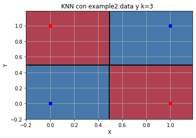

```python
exe_KNN_plot(dataset,estrategia,3,"example2.data",False)
```

Como hemos mencionado anteriormente, al tratarse de atributos discretos no normalizaremos. La tasa de error obtenida es de 0%, esto se debe a la gran separacion de ambas clases.

### example3.data

```python
dataset=Datos('data/example3.data')
```

```python
table3 = exe_KNN(dataset,estrategia, lista_k, True)

print("**Tasa de error [media ± desv.tip]**")
display(HTML(table3))
```

```
**Tasa de error [media ± desv.tip]**
```

| k | Sin Normalizar | Normalizando |
| --- | --- | --- |
| 1 | 0.0000 ± 0 | 0.0000 ± 0 |
| 3 | 0.0000 ± 0 | 0.0000 ± 0 |
| 5 | 0.0000 ± 0 | 0.0000 ± 0 |
| 11 | 0.0000 ± 0 | 0.0000 ± 0 |
| 21 | 0.0000 ± 0 | 0.0000 ± 0 |
| 51 | 0.0111 ± 0 | 0.0085 ± 0 |

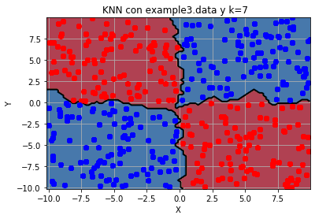

```python
exe_KNN_plot(dataset,estrategia,7,"example3.data",False)
```

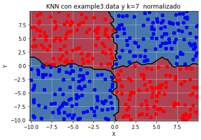

```python
exe_KNN_plot(dataset,estrategia,7,"example3.data",True)
```

Como podemos observar ambas soluciones, tanto normalizadas como sin normalizar obtienen resultados muy parecidos, practicamente el 0% en ambos casos. Se obtienen unas fronteras muy bien marcadas.

### example4.data

```python
dataset=Datos('data/example4.data')
```

```python
table4 = exe_KNN(dataset,estrategia, lista_k, True)

print("**Tasa de error [media ± desv.tip]**")
display(HTML(table4))
```

```
**Tasa de error [media ± desv.tip]**
```

| k | Sin Normalizar | Normalizando |
| --- | --- | --- |
| 1 | 0.0400 ± 0 | 0.0000 ± 0 |
| 3 | 0.0067 ± 0 | 0.0000 ± 0 |
| 5 | 0.0060 ± 0 | 0.0000 ± 0 |
| 11 | 0.0200 ± 0 | 0.0000 ± 0 |
| 21 | 0.0267 ± 0 | 0.0000 ± 0 |
| 51 | 0.0673 ± 0 | 0.0000 ± 0 |

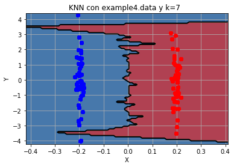

```python
exe_KNN_plot(dataset,estrategia,7,"example4.data",False)
```

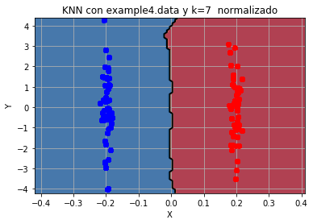

```python
exe_KNN_plot(dataset,estrategia,7,"example4.data",True)
```

Al igual que en los casos anteriores en la grafica normalizada se pueden ver unas fronteras bien marcadas.

### wdbc.data

```python
dataset=Datos('data/wdbc.data')
```

```python
table_wdbc = exe_KNN(dataset,estrategia, lista_k, True)

print("**Tasa de error [media ± desv.tip]**")
display(HTML(table_wdbc))
```

```
**Tasa de error [media ± desv.tip]**
```

| k | Sin Normalizar | Normalizando |
| --- | --- | --- |
| 1 | 0.0192 ± 0 | 0.0031 ± 0 |
| 3 | 0.0150 ± 0 | 0.0043 ± 0 |
| 5 | 0.0101 ± 0 | 0.0025 ± 0 |
| 11 | 0.0295 ± 0 | 0.0102 ± 0 |
| 21 | 0.0329 ± 0 | 0.0186 ± 0 |
| 51 | 0.0554 ± 0 | 0.0182 ± 0 |

El error obtenido es de aproximadamente un 5% sin normalizar y un 1% normalizando.

En este caso, al no tratarse de un conjunto de datos bidimensional, no podemos representarlo.

## Clasificador regresion logistica

Los parametros de este clasificador seran, numero de epocas, constante de aprendizaje y si queremos que los datos con los que trabajamos esten normalizados.

Declaramos las epocas con las que vamos a ejecutar el clasificador.

```python
n_epocas = [1, 5, 10, 15, 20]
```

### example1.data

```python
dataset=Datos('data/example1.data')
```

```python
table1 = exe_REG_LOG(dataset,estrategia,n_epocas, True)

print("**Tasa de error [media ± desv.tip]**")
display(HTML(table1))
```

```
**Tasa de error [media ± desv.tip]**
```

| N epocas | Sin Normalizar | Normalizando |
| --- | --- | --- |
| 1 | 0.4875 ± 0 | 0.5350 ± 0 |
| 5 | 0.5275 ± 0 | 0.5862 ± 0 |
| 10 | 0.4845 ± 0 | 0.5079 ± 0 |
| 15 | 0.5011 ± 0 | 0.4081 ± 0 |
| 20 | 0.4992 ± 0 | 0.4108 ± 0 |

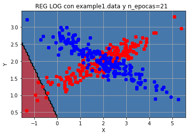

```python
exe_REG_LOG_plot(dataset,estrategia,21,"example1.data",False)
```

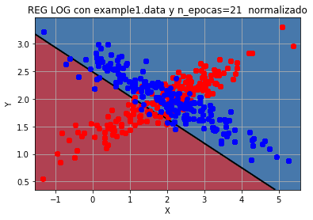

```python
exe_REG_LOG_plot(dataset,estrategia,21,"example1.data",True)
```

Como se puede apreciar en las dos representaciones, ambas clasificaciones son malas, ya que los puntos no se situan en su color correctamente. El error obtenido es del 50% aproximadamente tanto con datos normalizados como sin normalizar.

### example2.data

Al igual que haciamos en vecinos proximos este algoritmo se ejecutara sin normalizar, ya que se trata de atributos discretos.

```python
dataset=Datos('data/example2.data')
```

```python
table2 = exe_REG_LOG(dataset,estrategia,n_epocas, False)

print("**Tasa de error [media ± desv.tip]**")
display(HTML(table2))
```

```
**Tasa de error [media ± desv.tip]**
```

| N epocas | Sin Normalizar |
| --- | --- |
| 1 | 0.2983 ± 0 |
| 5 | 0.2493 ± 0 |
| 10 | 0.4500 ± 0 |
| 15 | 0.4988 ± 0 |
| 20 | 0.5000 ± 0 |

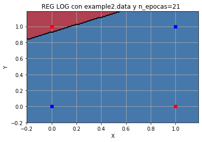

```python
exe_REG_LOG_plot(dataset,estrategia,21,"example2.data",False)
```

### example3.data

```python
dataset=Datos('data/example3.data')
```

```python
table3 = exe_REG_LOG(dataset,estrategia,n_epocas, True)

print("**Tasa de error [media ± desv.tip]**")
display(HTML(table3))
```

```
**Tasa de error [media ± desv.tip]**
```

| N epocas | Sin Normalizar | Normalizando |
| --- | --- | --- |
| 1 | 0.4929 ± 0 | 0.5000 ± 0 |
| 5 | 0.5244 ± 0 | 0.5205 ± 0 |
| 10 | 0.5233 ± 0 | 0.5080 ± 0 |
| 15 | 0.4819 ± 0 | 0.4968 ± 0 |
| 20 | 0.5224 ± 0 | 0.4174 ± 0 |

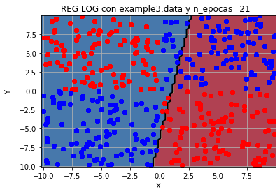

```python
exe_REG_LOG_plot(dataset,estrategia,21,"example3.data",False)
```

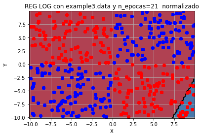

```python
exe_REG_LOG_plot(dataset,estrategia,21,"example3.data",True)
```

Nos vuelve a ocurrir lo mismo que en los conjuntos de datos anteriores, y obtenemos un error del 50%, tanto normalizando como sin normalizar.

### example4.data

```python
dataset=Datos('data/example4.data')
```

```python
table4 = exe_REG_LOG(dataset,estrategia, n_epocas, True)

print("**Tasa de error [media ± desv.tip]**")
display(HTML(table4))
```

```
**Tasa de error [media ± desv.tip]**
```

| N epocas | Sin Normalizar | Normalizando |
| --- | --- | --- |
| 1 | 0.0100 ± 0 | 0.0000 ± 0 |
| 5 | 0.0000 ± 0 | 0.0000 ± 0 |
| 10 | 0.0000 ± 0 | 0.0000 ± 0 |
| 15 | 0.0000 ± 0 | 0.0000 ± 0 |
| 20 | 0.0000 ± 0 | 0.0000 ± 0 |

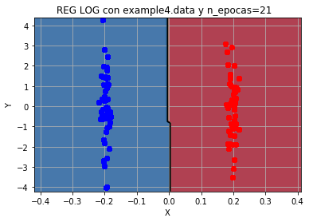

```python
exe_REG_LOG_plot(dataset,estrategia,21,"example4.data",False)
```

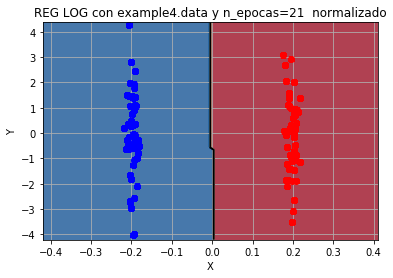

```python
exe_REG_LOG_plot(dataset,estrategia,21,"example4.data",True)
```

En este caso podemos observar que la tasa de error es del 0%. Esto se debe a que los puntos se concentran en dos regiones permitiendonos separarlos de manera correcta.

### wdbc.data

```python
dataset=Datos('data/wdbc.data')
```

```python
table_wdbc = exe_REG_LOG(dataset,estrategia,n_epocas, True)

print("**Tasa de error [media ± desv.tip]**")
display(HTML(table_wdbc))
```

```
**Tasa de error [media ± desv.tip]**
```

| N epocas | Sin Normalizar | Normalizando |
| --- | --- | --- |
| 1 | 0.1859 ± 0 | 0.0396 ± 0 |
| 5 | 0.1487 ± 0 | 0.0277 ± 0 |
| 10 | 0.1539 ± 0 | 0.0230 ± 0 |
| 15 | 0.1439 ± 0 | 0.0250 ± 0 |
| 20 | 0.0856 ± 0 | 0.0193 ± 0 |

Al no tratarse de una tabla bidimensional, al igual que nos ocurria con vecinos proximos no podemos realizar una representacion grafica.

El error obtenido es de un 15% sin normalizar y un 5% normalizado, considerablemente mejor que en los tres primeros casos.

## Clasificador vecinos proximos con SCKLearn

Probaremos el algoritmo con los mismos valores de k para poder comparar nuestros resultados con los obtenidos con ScikitLearn.

```python
lista_k = [1, 3, 5, 11, 21, 51]
```

```python
dataset=Datos('data/example1.data')
tableKnn1 = p2_scikit.Knn_Scikit(dataset, estrategia, lista_k)
display(HTML(tableKnn1))
```

| K vecinos | Error |
| --- | --- |
| 1 | 0.1700 ± 0 |
| 3 | 0.1425 ± 0 |
| 5 | 0.1350 ± 0 |
| 11 | 0.1375 ± 0 |
| 21 | 0.1425 ± 0 |
| 51 | 0.1250 ± 0 |

### example2.data

```python
dataset=Datos('data/example2.data')
tableKnn2 = p2_scikit.Knn_Scikit(dataset, estrategia, lista_k)
display(HTML(tableKnn2))
```

| K vecinos | Error |
| --- | --- |
| 1 | 0.0000 ± 0 |
| 3 | 0.0000 ± 0 |
| 5 | 0.0000 ± 0 |
| 11 | 0.0000 ± 0 |
| 21 | 0.0000 ± 0 |
| 51 | 0.0000 ± 0 |

### example3.data

```python
dataset=Datos('data/example3.data')
tableKnn3 = p2_scikit.Knn_Scikit(dataset, estrategia, lista_k)
display(HTML(tableKnn3))
```

| K vecinos | Error |
| --- | --- |
| 1 | 0.0275 ± 0 |
| 3 | 0.0375 ± 0 |
| 5 | 0.0325 ± 0 |
| 11 | 0.0225 ± 0 |
| 21 | 0.0300 ± 0 |
| 51 | 0.0300 ± 0 |

### example4.data

```python
dataset=Datos('data/example4.data')
tableKnn4 = p2_scikit.Knn_Scikit(dataset, estrategia, lista_k)
display(HTML(tableKnn4))
```

| K vecinos | Error |
| --- | --- |
| 1 | 0.0300 ± 0 |
| 3 | 0.0900 ± 0 |
| 5 | 0.1100 ± 0 |
| 11 | 0.2000 ± 0 |
| 21 | 0.3400 ± 0 |
| 51 | 0.5200 ± 0 |

## Clasificador regresion logistica con SCKLearn

Al igual que en el clasificador anterior, el numero de epocas que usaremos sera el mismo que con nuestro clasificador para poder comparar despues resultados.

```python
n_epocas = [1, 5, 10, 15, 20]
```

### example1.data

```python
dataset=Datos('data/example1.data')
tableRegLog1 = p2_scikit.RegLog_Scikit(dataset, estrategia, n_epocas)
display(HTML(tableRegLog1))
```

| N epocas | Error |
| --- | --- |
| 1 | 0.5625 ± 0 |
| 5 | 0.5625 ± 0 |
| 10 | 0.5625 ± 0 |
| 15 | 0.5625 ± 0 |
| 20 | 0.5625 ± 0 |

### example2.data

```python
dataset=Datos('data/example2.data')
tableRegLog2 = p2_scikit.RegLog_Scikit(dataset, estrategia, n_epocas)
display(HTML(tableRegLog2))
```

| N epocas | Error |
| --- | --- |
| 1 | 0.5500 ± 0 |
| 5 | 0.5500 ± 0 |
| 10 | 0.5500 ± 0 |
| 15 | 0.5500 ± 0 |
| 20 | 0.5500 ± 0 |

### example3.data

```python
dataset=Datos('data/example3.data')
tableRegLog3 = p2_scikit.RegLog_Scikit(dataset, estrategia, n_epocas)
display(HTML(tableRegLog3))
```

| N epocas | Error |
| --- | --- |
| 1 | 0.5375 ± 0 |
| 5 | 0.5350 ± 0 |
| 10 | 0.5350 ± 0 |
| 15 | 0.5350 ± 0 |
| 20 | 0.5350 ± 0 |

### example4.data

```python
dataset=Datos('data/example4.data')
tableRegLog4 = p2_scikit.RegLog_Scikit(dataset, estrategia, n_epocas)
display(HTML(tableRegLog4))
```

| N epocas | Error |
| --- | --- |
| 1 | 0.0000 ± 0 |
| 5 | 0.0000 ± 0 |
| 10 | 0.0000 ± 0 |
| 15 | 0.0000 ± 0 |
| 20 | 0.0000 ± 0 |